# ST-540 Assignment-3

Tilekbek Zhoroev

1/26/2022

**Problem 1**

Assume that $(X; Y )$ follow the bivariate normal distribution and that both $X$ and $Y$ have marginal mean zero and marginal variance one. We observe six independent and identically distributed data points: $(-3.3, -2.6), (0.1, -0.2), (-1.1, -1.5), (2.7, 1.5), (2.0, 1.9)$ and $(-0.4, -0.3)$. Make a scatter plot of the data and, assuming the correlation parameter $\rho$ has a Uniform(-1; 1) prior, plot the posterior distribution of $\rho$.

*Solution*

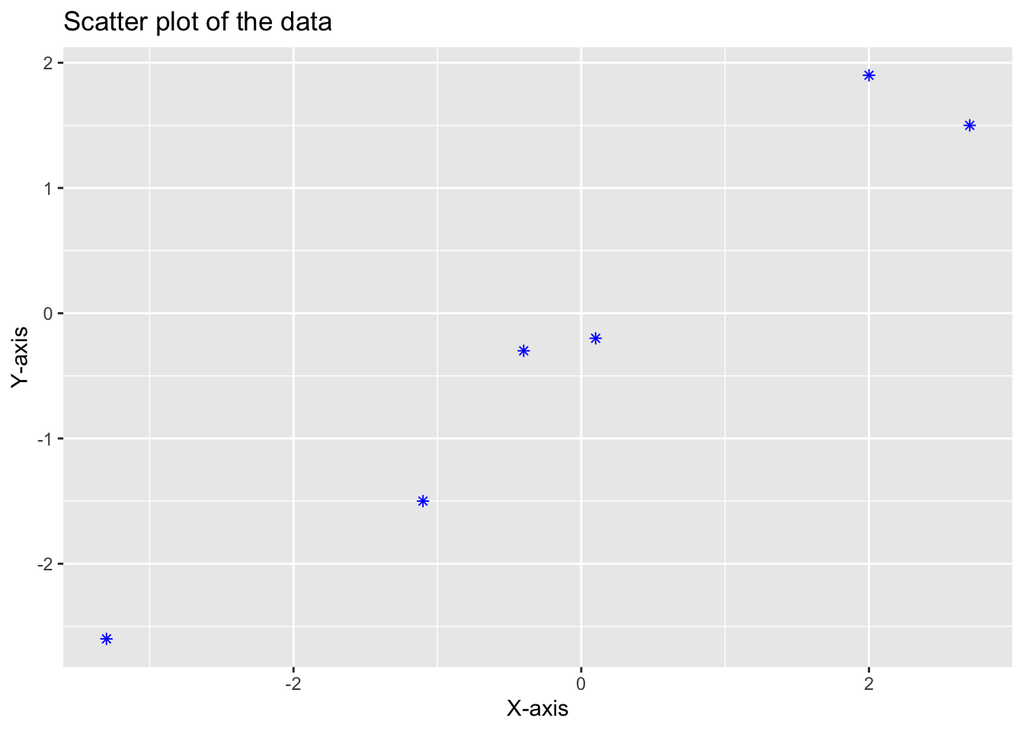

```r
df<-data.frame(X=c(-3.3, 0.1, -1.1, 2.7, 2.0, -0.4), Y=c(-2.6, -0.2, -1.5, 1.5, 1.9, -0.3))
df%>%
  ggplot(aes(x=X, y=Y))+
  geom_point(shape = 8, colour="blue")+
  labs(title = "Scatter plot of the data", x = "X-axis", y="Y-axis")
```

```r
sum(df^2)
```

```
## [1] 38.56
```

```r
sum(df$X*df$Y)
```

```
## [1] 18.18
```

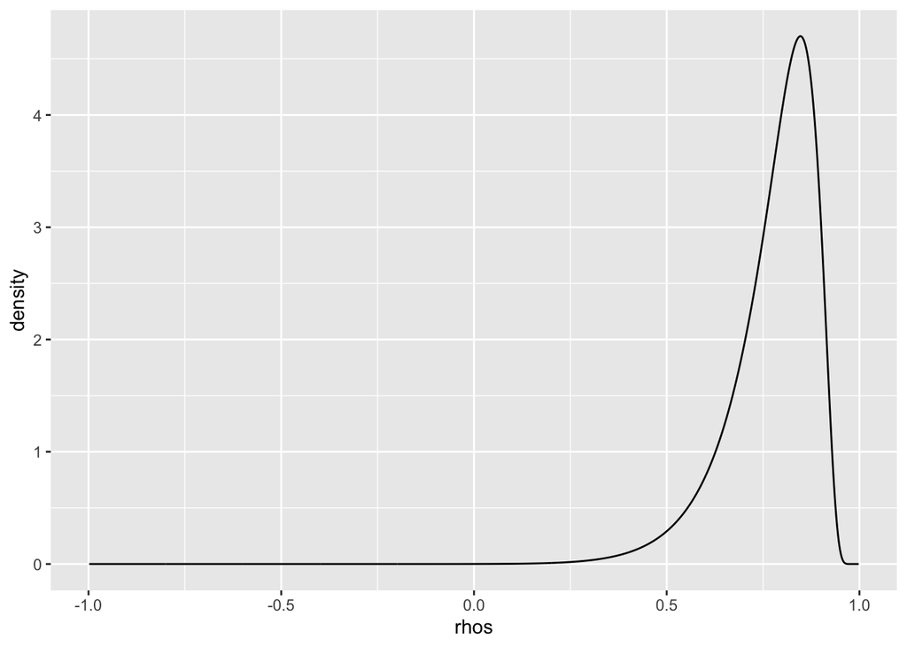

```r
post<-function(rho){1/(1-rho^2)^3*exp(-(38.56-rho*36.36)/(2-2*rho^2))}
# normalization factor
int_val<-integrate(post, lower = -1, upper = 1)$value
# since rho is between -1, 1 take sequence between this points,
rhos <- seq(-1,1, length.out=1000)
# posterior distribution values
density <- sapply(rhos, post)/int_val
data.frame(rhos, density)%>%
  filter(!is.na(density))%>%
  ggplot(aes(x=rhos,y=density))+
  geom_line()
```

**Problem 2**

The normalized difference vegetation index (NDVI) is commonly used to classify land cover using remote sensing data. Hypothetically, say that NDVI follows a Beta(25; 10) distribution for pixels in a rain forest, and a Beta(10; 15) distribution for pixels in a deforested area now used for agriculture. Assuming about 10% of the rain forest has been deforested, your objective is to build a rule to classify individual pixels as deforested based on their NDVI.

> 1. Plot the PDF of NDVI for forested and deforested pixels, and the marginal distribution of NDVI averaging over categories.>
> 2. Give an expression for the probability that a pixel is deforested given its NDVI value, and plot this probability by NDVI.>
> 3. You will classify a pixel as deforested if you are at least 90% sure it is deforested. Following this rule, give the range of NDVI that will lead to a pixel being classiffed as deforested.>

[output not shown]